# Chapter 1 - examples

Alicja Wolny-Dominiak

24 listopada 2017

#### Example - estimation of $(\lambda, \alpha)'$ in Gamma Distribution

There are at least three equivalent methods in `R` that can be used to obtain ML estimates of the parameters in Gamma distribution. In the first method, we implement the two-parameter log-likelihood of Gamma distribution, and basic function `optim` is applied.

```r
options(digits=2)

y.gam <- rgamma(100, 2)

l.gamma <- function(y,par) {n<-length(y)
-n*par[2]*log(par[1])+n*log(gamma(par[2]))-(par[2]-1)*sum(log(y))+par[1]*sum(y)} # -log-likelihood function
result <- optim( par = c(1,2), l.gamma, y = y.gam, method = "Nelder-Mead")
result[1]
```

```
## $par
## [1] 0.89 1.65
```

```r
result[2]
```

```
## $value
## [1] 155
```

```r
library(stats4)
l.gamma<-function(lambda,alfa) {y<-y.gam
n<-length(y)
-n*alfa*log(lambda)+n*log(gamma(alfa))-(alfa-1)*sum(log(y))+lambda*sum(y)} # -log-likelihood function
est<-mle(minuslog=l.gamma, start=list(lambda=1,alfa=2))
summary(est)
```

```
## Maximum likelihood estimation
##
## Call:
## mle(minuslogl = l.gamma, start = list(lambda = 1, alfa = 2))
##
## Coefficients:
##        Estimate Std. Error
## lambda     0.89       0.14
## alfa       1.65       0.21
##
## -2 log L: 309
```

```r
library(MASS)
fitdistr(y.gam,"gamma", method = "Nelder-Mead") # fitting gamma pdf parameters
```

```
##   shape    rate
##   1.65    0.89
##  (0.21)  (0.14)
```

#### Example - fitting GLM Inverse-Gaussian

In this example, data set `dataCar` taken from package `insuranceData` is based on one-year vehicle insurance policies taken out in 2004 or 2005. There are 67,856 policies, of which 4624 (6.8%) had at least one claim.

```r
options(digits=2)

library(insuranceData)

data(dataCar)
attach(dataCar)

glm.ig <- glm(claimcst0[dataCar$claimcst0>0]~as.factor(veh_age[dataCar$claimcst0>0]),
family=inverse.gaussian(link="log"), data=dataCar)
summary(glm.ig)
```

```
##
## Call:
## glm(formula = claimcst0[dataCar$claimcst0 > 0] ~ as.factor(veh_age[dataCar$claimcst0 >
##     0]), family = inverse.gaussian(link = "log"), data = dataCar)
##
## Deviance Residuals:
##      Min        1Q    Median        3Q       Max
## -0.06419  -0.04364  -0.02216   0.00102   0.11552
##
## Coefficients:
##                                            Estimate Std. Error t value
## (Intercept)                                  7.5418     0.0603  125.07
## as.factor(veh_age[dataCar$claimcst0 > 0])2   0.0464     0.0783    0.59
## as.factor(veh_age[dataCar$claimcst0 > 0])3   0.0570     0.0773    0.74
## as.factor(veh_age[dataCar$claimcst0 > 0])4   0.1402     0.0810    1.73
##                                            Pr(>|t|)
## (Intercept)                                  <2e-16 ***
## as.factor(veh_age[dataCar$claimcst0 > 0])2    0.553
## as.factor(veh_age[dataCar$claimcst0 > 0])3    0.461
## as.factor(veh_age[dataCar$claimcst0 > 0])4    0.084 .
## ---
## Signif. codes:  0 '***' 0.001 '**' 0.01 '*' 0.05 '.' 0.1 ' ' 1
##
## (Dispersion parameter for inverse.gaussian family taken to be 0.0016)
##
##     Null deviance: 6.4422  on 4623  degrees of freedom
## Residual deviance: 6.4369  on 4620  degrees of freedom
## AIC: 77190
##
## Number of Fisher Scoring iterations: 9
```

```r
mean.group <-tapply(claimcst0[dataCar$claimcst0>0], as.factor(veh_age[dataCar$claimcst0>0]), mean)
data.frame("mean"=mean.group, "fitted values"=unique(glm.ig$fitted.values))
```

```
##   mean fitted.values
## 1 1885          1996
## 2 1975          1975
## 3 1996          1885
## 4 2169          2169
```

```r
mean.group
```

```
##    1    2    3    4
## 1885 1975 1996 2169
```

#### Example - Density of Tweedie Distribution

The graph of Tweedie density assuming different powers $p$.

```r
library(tweedie)
y=seq(0,4,length=1000)

d1 <-dtweedie( y, power=1.5, mu=1, phi=1)
d2 <-dtweedie( y, power=2, mu=1, phi=1)
d3 <-dtweedie( y, power=2.5, mu=1, phi=1)
d4 <-dtweedie( y, power=5, mu=1, phi=1)
```

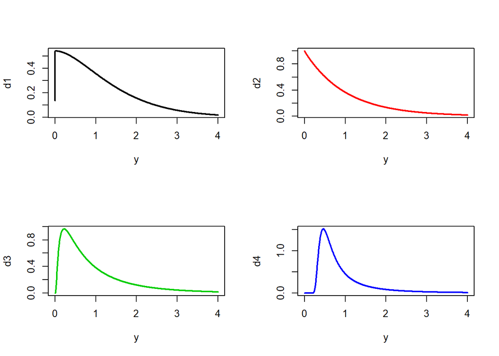

#### Example - fitting DGLM Poisson

We fit the parameters of Poisson in which the response variable of interest is `Claims`. Variable `Insured` is treated as the exposure to risk, and the dispersion is modeled with variable `Make`. The `R` code and output are presented below. Figure shows the diagnostic plots.

```r
library(dglm)
library(faraway)

attach(motorins)
Kilom <-as.factor(Kilometres)
Bonus <-as.factor(Bonus)
Make <-as.factor(Make)

dglm.claims <-dglm(Claims~Kilom+Bonus+Make, offset=log(motorins$Insured),
~Make, family=poisson(link="log"), data=motorins)
summary(dglm.claims)
```

```
##
## Call: dglm(formula = Claims ~ Kilom + Bonus + Make, dformula = ~Make,
##     family = poisson(link = "log"), data = motorins, offset = log(motorins$Insured))
##
## Mean Coefficients:
##             Estimate Std. Error z value Pr(>|z|)
## (Intercept)    2.537      0.091    27.8 2.5e-170
## Kilom.L       -0.896      0.063   -14.1  2.4e-45
## Kilom.Q       -0.333      0.059    -5.6  1.8e-08
## Kilom.C        0.410      0.060     6.9  6.4e-12
## Kilom^4        0.092      0.053     1.7  8.6e-02
## Bonus          0.278      0.013    21.9 1.1e-106
## Make2         -1.377      0.090   -15.2  2.5e-52
## Make3         -1.639      0.097   -16.9  3.4e-64
## Make4         -1.484      0.131   -11.4  6.7e-30
## Make5         -1.237      0.089   -13.9  5.0e-44
## Make6         -0.857      0.093    -9.3  2.0e-20
## Make7         -1.568      0.089   -17.6  5.6e-69
## Make8         -2.156      0.098   -22.0 7.5e-107
## Make9          1.935      0.091    21.3 4.0e-101
## (Dispersion Parameters for poisson family estimated as below )
##
##     Scaled Null Deviance: 4193 on 1796 degrees of freedom
## Scaled Residual Deviance: 1797 on 1783 degrees of freedom
##
## Dispersion Coefficients:
##             Estimate Std. Error z value Pr(>|z|)
## (Intercept)     3.83      0.094    40.8  0.0e+00
## Make2          -1.38      0.136   -10.1  5.5e-24
## Make3          -1.52      0.142   -10.8  4.9e-27
## Make4          -0.53      0.147    -3.6  2.9e-04
## Make5          -1.33      0.136    -9.8  1.8e-22
## Make6          -0.76      0.135    -5.6  1.7e-08
## Make7          -1.66      0.138   -12.0  2.3e-33
## Make8          -1.99      0.143   -14.0  2.7e-44
## Make9           2.05      0.130    15.7  1.2e-55
## (Dispersion parameter for Gamma family taken to be 2 )
##
##     Scaled Null Deviance: 4490 on 1796 degrees of freedom
## Scaled Residual Deviance: 2642 on 1788 degrees of freedom
##
## Minus Twice the Log-Likelihood: 14997
## Number of Alternating Iterations: 6
```

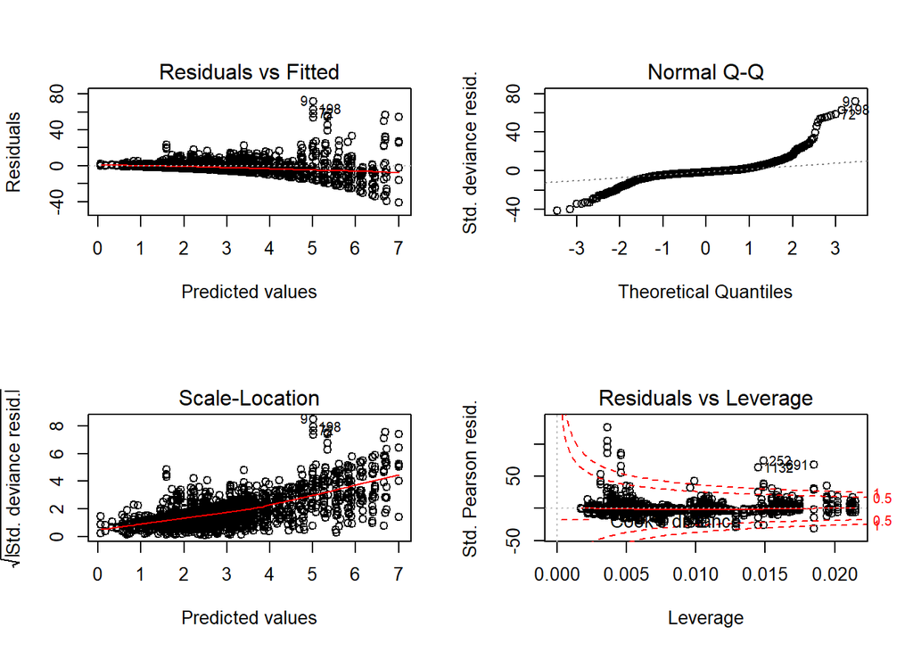

```r
##Figure
par(mfrow=c(2,2))
plot(dglm.claims)
```

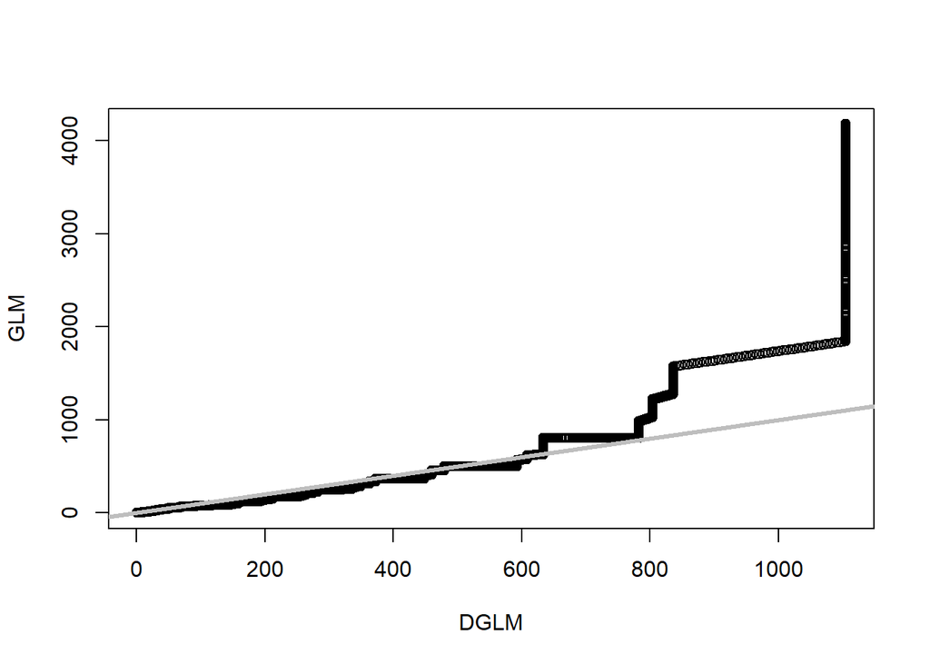

```r
glm.claims <-glm(Claims~Kilom+Bonus+Make, offset=log(motorins$Insured),
family=poisson(link="log"), data=motorins)

plot(quantile(dglm.claims$fitted.values, probs=seq(0,1,0.00001)),
quantile(glm.claims$fitted.values, probs=seq(0,1,0.00001)),
xlab="DGLM",
ylab="GLM" )
abline(0,1,lwd=3,col="gray")
```

#### Example - the estimation of $\lambda$ of Poisson distribution

```r
k <- rpois(20,4)
l.lambda <- function(lambda) {log(prod(((lambda^k)*exp(-lambda))/factorial(k)))}
optimize(f=l.lambda, interval = c(0,10), maximum=TRUE)
```

```
## $maximum
## [1] 4.4
##
## $objective
## [1] -43
```

#### Example - estimation of parameters in ZI distribution

We investigate the number of claims taken from data set `dataOhlsson{insuranceData}`. This data comes from the former Swedish insurance company Wasa and concerns partial casco insurance (this time, for motorcycles). It contains aggregated data on all insurance policies and claims during the period of 1994-1998.

```r
library(pscl)
library(insuranceData)
data(dataOhlsson)
number.of.claims <- dataOhlsson$antskad

table(number.of.claims)
```

```
## number.of.claims
##     0     1     2
## 63878   643    27
```

```r
zip.pois <-zeroinfl(number.of.claims~1, dist = "poisson")
zip.nb <-zeroinfl(number.of.claims~1, dist = "negbin")

lambda.pois <-exp(zip.pois$coefficients$count)
logit.tau.pois <-zip.pois$coefficients$zero
tau.pois <-exp(logit.tau.pois)/(1+exp(logit.tau.pois))

lambda.nb <-exp(zip.nb$coefficients$count)
logit.tau.nb <-zip.nb$coefficients$zero
tau.nb <-exp(logit.tau.nb)/(1+exp(logit.tau.nb))

##summary
cbind(lambda.pois, tau.pois, lambda.nb, tau.nb)
```

```
##             lambda.pois tau.pois lambda.nb tau.nb
## (Intercept)        0.08     0.86      0.08   0.86
```

#### Example - simulation random sample from ZINB and ZIP

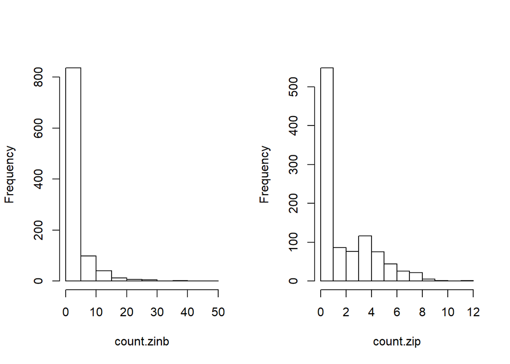

```r
library(gamlss.dist)
library(pscl)

count.zinb <- rZINBI(1000, mu=5, sigma=1, nu=0.5) #random sample from ZINB distribution
count.zip <- rZIP(1000, mu=4, sigma=0.5) #random sample from ZIP distribution

## Figure
par(mfrow=c(1,2))
hist(count.zinb, main="")
hist(count.zip, main="")
```

#### Example - the probability mass function of ZTPois

```r
dztpois <- function (y, lambda)
{
    n <- length(y)
    dztp <- vector(length=n)
    dztp[y>0] <- dpois(y[y>0], lambda)/(1 - dpois(0, lambda))
    return(dztp)
}
k <- rpois(5,lambda=5)
round(dztpois(k[k>0], lambda=5), digits=4)
```

```
## [1] 0.177 0.105 0.066 0.085 0.177
```

```r
k.plot <- 1:10
dk <- length(10)
for (i in 1:10) {
dk[i] <- dztpois(i, lambda=5)
}
dk
```

```
##  [1] 0.034 0.085 0.141 0.177 0.177 0.147 0.105 0.066 0.037 0.018
```

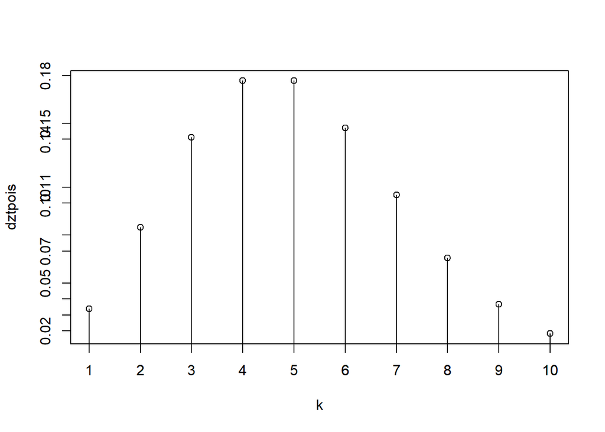

```r
##Figure
plot(k.plot, dk, type="h", xlab="k", ylab="dztpois", axes = FALSE)
axis(1, 1:10, 1:10)
axis(2, round(dk, digits=2))
par(new = T)
plot(k.plot, dk, type="p", xlab="", ylab="")
```

#### Example - the estimation of $\lambda$ in ZTPois

```r
k <- rpois(200,3)
k.nz <- as.data.frame(k[k>0])
X <- model.matrix(~1, k.nz)

beta <- coef(glm(k[k>0] ~ 1, family = poisson(link=log)))

ll.ztp <- function(beta){
lambda <- exp(X %*% beta)
ll <-  sum(k[k>0]*log(lambda) - log(exp(lambda)-1)-log(factorial(k[k>0])))
return(-ll)
}
opt <- optim(beta, ll.ztp, hessian = TRUE, method = "BFGS")
log.likelihood <- (-opt$value)
opt$par
```

```
## (Intercept)
##         1.1
```

```r
log.likelihood
```

```
## [1] -342
```

```r
opt$hessian
```

```
##             (Intercept)
## (Intercept)         496
```

#### Example - simulation Tweedie’s compound Poisson distribution

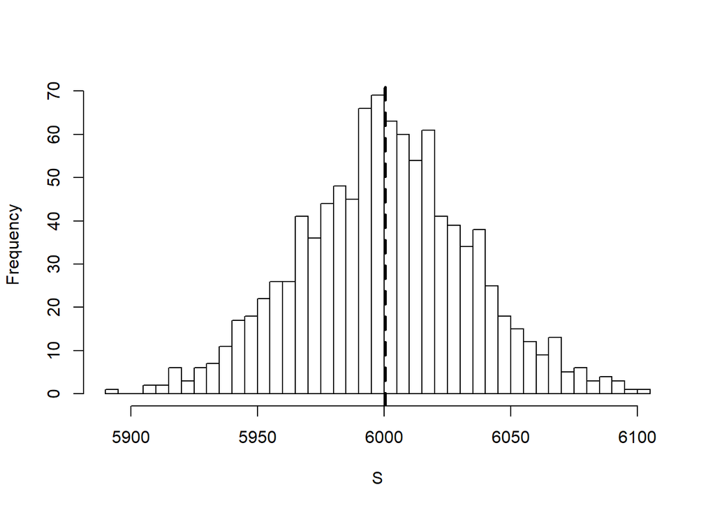

```r
library(tweedie)
library(statmod)

lambda=2
iota=30
varsigma=.2

mu=lambda*iota*varsigma
p=(iota+2)/(iota+1)
phi=lambda^(1-p)*(iota*varsigma)^(2-p)/(2-p)

n=1000
S=NULL
for (i in 1:n){
S[i] <-sum(rgamma(rpois(n,lambda),shape=iota,scale=varsigma))
S=cbind(S,S[i])
 }

##Figure
hist(S, breaks=30, main="")
abline(v=mean(S), lty=2, lwd=3)
```

#### Example - estimation of Tweedie’s compound Poisson parameters

Response `Claim` from portfolio `IndustryAuto{insuranceData}` is modeled assuming a `TCPoisson` model without regressors. We fit the model parameters using function `cpglm`.

```r
library(insuranceData)
library(cplm)
data(IndustryAuto)

cpglm <- cpglm(Claim~1, link="log", data=IndustryAuto)
summary(cpglm)
```

```
##
## Call:
## cpglm(formula = Claim ~ 1, link = "log", data = IndustryAuto)
##
## Deviance Residuals:
##    Min      1Q  Median      3Q     Max
## -119.1   -23.6    18.1    30.9    60.0
##             Estimate Std. Error t value Pr(>|t|)
## (Intercept)   10.595      0.034     312   <2e-16 ***
## ---
## Signif. codes:  0 '***' 0.001 '**' 0.01 '*' 0.05 '.' 0.1 ' ' 1
##
## Estimated dispersion parameter: 2404.5
## Estimated index parameter: 1.01
##
## Residual deviance: 139097  on 54  degrees of freedom
## AIC:  1174
##
## Number of Fisher Scoring iterations:  4
```

```r
cbind("Intercept"=cpglm$coefficients, "Power p"=cpglm$p, "Dispersion"=cpglm$phi)
```

```
##             Intercept Power p Dispersion
## (Intercept)        11       1       2405
```

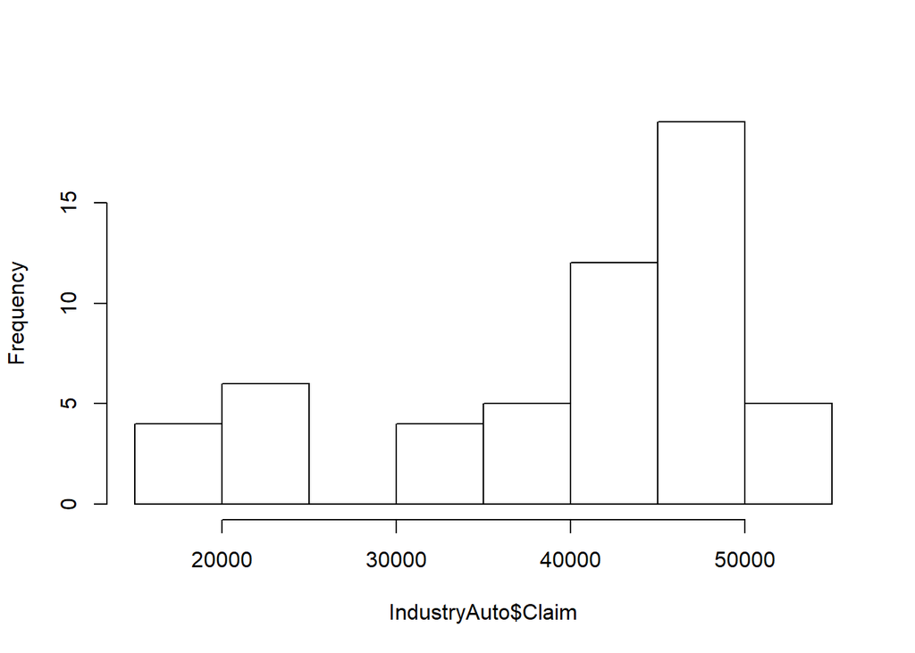

```r
##Figure
hist(IndustryAuto$Claim, main="")
```

## Fixed Effect Models in Ratemaking

#### Example - Zero-inflated TCPoisson Model

Here, we analyze the response variable that is the aggregate value of claims `claimscst0` for the single risk observed in insurance portfolio ’dataCar{insuranceData}`. We start with the calculation of the expected value and the variance of this variable.

```r
library(insuranceData)
data(dataCar)
attach(dataCar)

group <-interaction(gender,veh_age,agecat)

mean(claimcst0)
```

```
## [1] 137
```

```r
var(claimcst0)
```

```
## [1] 1115765
```

```r
tweedie.zi <-zcpglm(claimcst0~gender+as.factor(veh_age)+agecat + offset(exposure)||agecat, data=dataCar)
tweedie.zi
```

```
##
## Call:
## zcpglm(formula = claimcst0 ~ gender + as.factor(veh_age) + agecat +
##     offset(exposure) || agecat, data = dataCar)
##
## Zero-inflation model coefficients:
##             Estimate Std. Error z value Pr(>|z|)
## (Intercept)   -6.647      2.326   -2.86   0.0043 **
## agecat         0.744      0.412    1.81   0.0705 .
##
## Compound Poisson model coefficients:
##                     Estimate Std. Error z value Pr(>|z|)
## (Intercept)           4.7328     0.0782   60.49  < 2e-16 ***
## genderM               0.1940     0.0442    4.39  1.1e-05 ***
## as.factor(veh_age)2   0.1639     0.0685    2.39    0.017 *
## as.factor(veh_age)3   0.0628     0.0666    0.94    0.346
## as.factor(veh_age)4   0.0817     0.0673    1.21    0.224
## agecat               -0.1401     0.0173   -8.10  5.5e-16 ***
## ---
## Signif. codes:  0 '***' 0.001 '**' 0.01 '*' 0.05 '.' 0.1 ' ' 1
##
## Estimated dispersion parameter: 267.73
## Estimated index parameter: 1.5657
```

The full code of the chapter 1 is available on GitHub.